# Project Multivariate data Analysis

Sara Vasques

Rita Pinto

Juan Pablo Martinez Aldana

2025-12-08

```r
# 2. Create folder if it doesn't exist
out_dir <- file.path("./plots")   # change base path if needed
```

# Dataset

The dataset contains the following variables:

**so2**: Sulfur dioxide content of air in micrograms per cubic meter

**temp**: Average annual temperature in Fahrenheit

**manuf**: Number of manufacturing enterprises employing 20 or more workers

**pop**: Population size (1970 census) in thousands

**wind**: Average wind speed in miles per hour

**precip**: Average annual precipitation in inches

**days**: Average number of days with precipitation per year

# Preliminary analysis of the data

Before applying multivariate methods, a preliminary analysis is essential to understand the individual variables and their pairwise relationships.

```
##       city so2 temp manuf pop wind precip days
## 1  Phoenix  10 70.3   213 582  6.0   7.05   36
## 2 Little R  13 61.0    91 132  8.2  48.52  100
## 3 San Fran  12 56.7   453 716  8.7  20.66   67
## 4   Denver  17 51.9   454 515  9.0  12.95   86
## 5 Hartford  56 49.1   412 158  9.0  43.37  127
## 6 Wilmingt  36 54.0    80  80  9.0  40.25  114
```

```
## [1] 41  8
```

```
## 'data.frame':    41 obs. of  8 variables:
##  $ city  : chr  "Phoenix" "Little R" "San Fran" "Denver" ...
##  $ so2   : int  10 13 12 17 56 36 29 14 10 24 ...
##  $ temp  : num  70.3 61 56.7 51.9 49.1 54 57.3 68.4 75.5 61.5 ...
##  $ manuf : int  213 91 453 454 412 80 434 136 207 368 ...
##  $ pop   : int  582 132 716 515 158 80 757 529 335 497 ...
##  $ wind  : num  6 8.2 8.7 9 9 9 9.3 8.8 9 9.1 ...
##  $ precip: num  7.05 48.52 20.66 12.95 43.37 ...
##  $ days  : int  36 100 67 86 127 114 111 116 128 115 ...
```

## Numerical Data

```
##   so2 temp manuf pop wind precip days
## 1  10 70.3   213 582  6.0   7.05   36
## 2  13 61.0    91 132  8.2  48.52  100
## 3  12 56.7   453 716  8.7  20.66   67
## 4  17 51.9   454 515  9.0  12.95   86
## 5  56 49.1   412 158  9.0  43.37  127
## 6  36 54.0    80  80  9.0  40.25  114
```

## Descriptive Statistics

```
##       so2              temp           manuf             pop
##  Min.   :  8.00   Min.   :43.50   Min.   :  35.0   Min.   :  71.0
##  1st Qu.: 13.00   1st Qu.:50.60   1st Qu.: 181.0   1st Qu.: 299.0
##  Median : 26.00   Median :54.60   Median : 347.0   Median : 515.0
##  Mean   : 30.05   Mean   :55.76   Mean   : 463.1   Mean   : 608.6
##  3rd Qu.: 35.00   3rd Qu.:59.30   3rd Qu.: 462.0   3rd Qu.: 717.0
##  Max.   :110.00   Max.   :75.50   Max.   :3344.0   Max.   :3369.0
##       wind            precip           days
##  Min.   : 6.000   Min.   : 7.05   Min.   : 36.0
##  1st Qu.: 8.700   1st Qu.:30.96   1st Qu.:103.0
##  Median : 9.300   Median :38.74   Median :115.0
##  Mean   : 9.444   Mean   :36.77   Mean   :113.9
##  3rd Qu.:10.600   3rd Qu.:43.11   3rd Qu.:128.0
##  Max.   :12.700   Max.   :59.80   Max.   :166.0
```

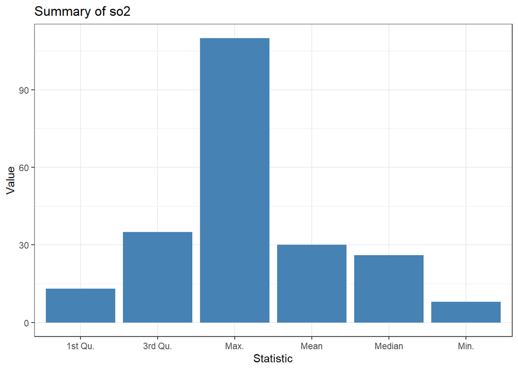

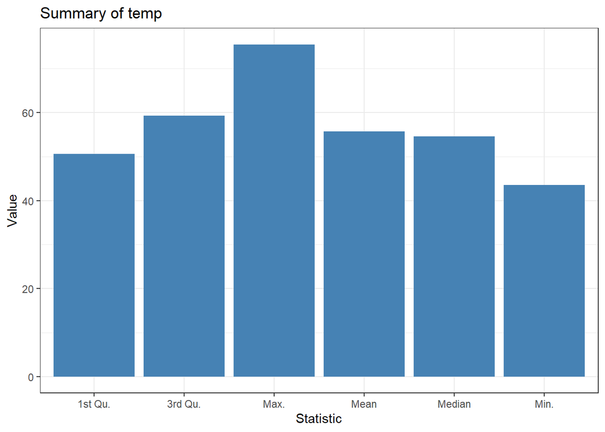

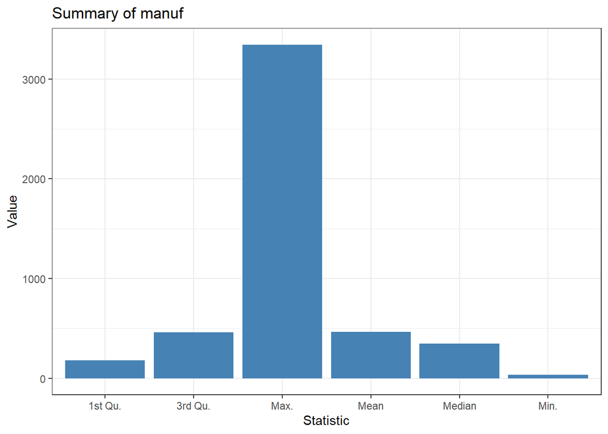

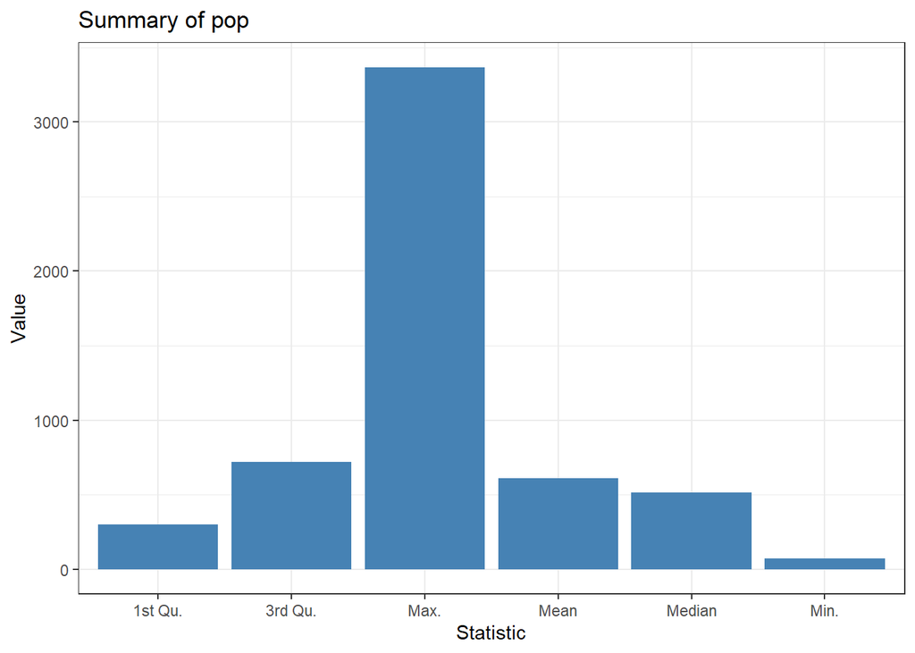

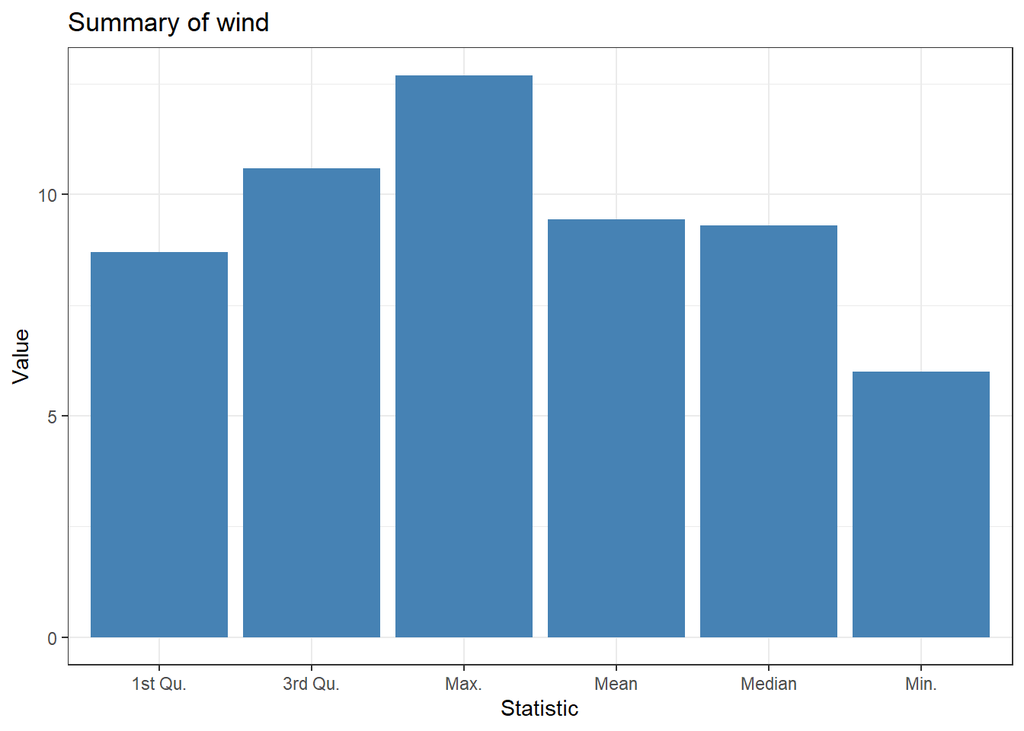

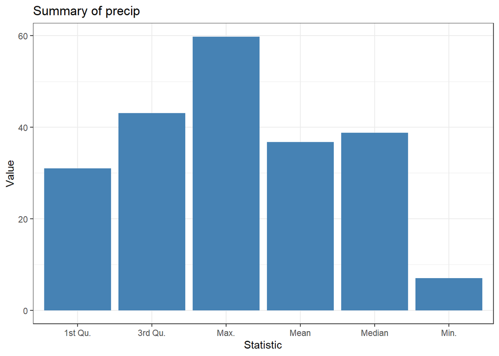

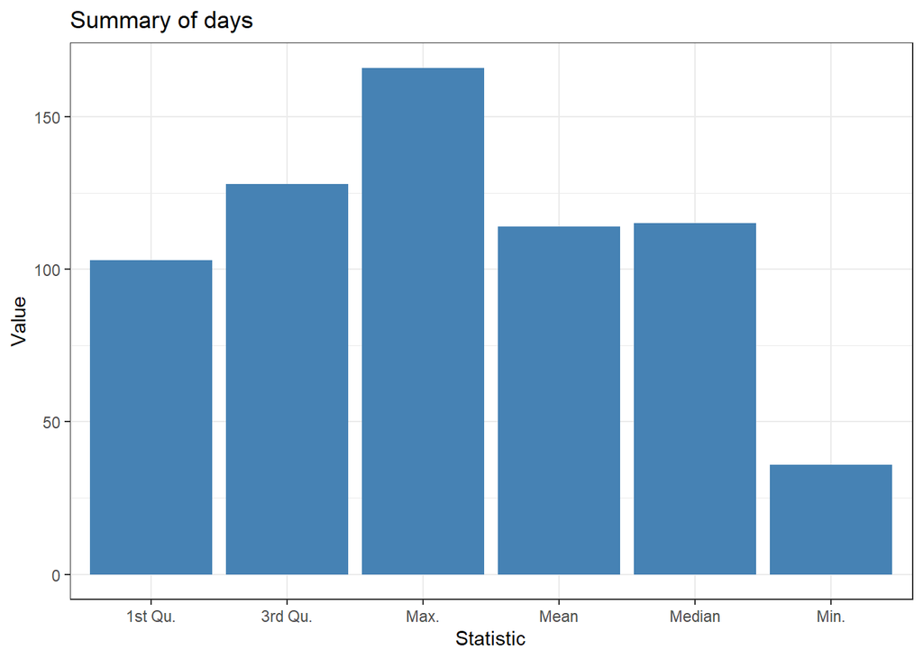

```r
#graphical representation of summary values
num_data <- data5_variables[sapply(data5_variables, is.numeric)]

library(ggplot2)
for (var in names(num_data)) {

  x <- num_data[[var]]

  s <- summary(x)
  summary_df <- data.frame(
    Statistic = names(s),
    Value = as.numeric(s)
  )

  print(
    ggplot(summary_df, aes(x = Statistic, y = Value)) +
      geom_col(fill = "steelblue") +
      labs(title = paste("Summary of", var),
           x = "Statistic",
           y = "Value") +
      theme_bw()
  )
}
```

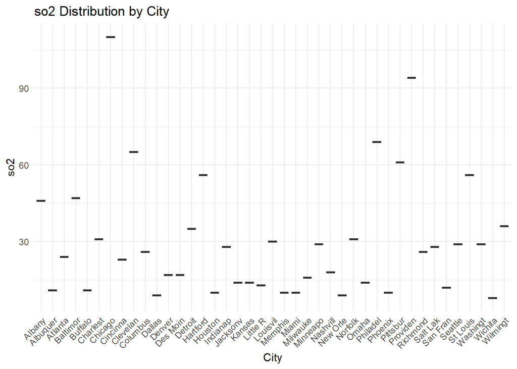

```r
#so2 Distribution by City
ggplot(data5, aes(x = city, y = so2)) +
  geom_boxplot(fill = "lightgreen") +
  theme_minimal() +
  labs(title = "so2 Distribution by City", x = "City", y = "so2") +
  theme(axis.text.x = element_text(angle = 45, hjust = 1))
```

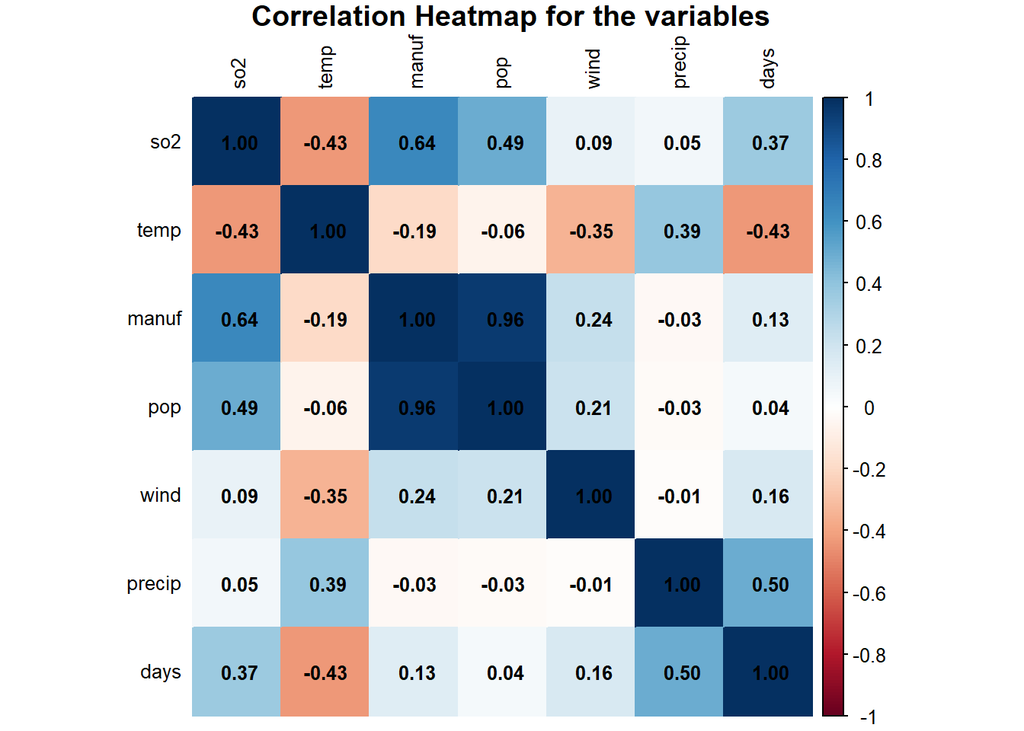

```r
#correlation heatmap of the numeric variables

# install.packages(c("corrplot", "reshape2"))
library(corrplot)
library(reshape2)
corr_matrix <- cor(data5_variables, use = "complete.obs")  # handles missing values

# Basic correlation heatmap
corrplot(corr_matrix, method = "color",
         addCoef.col = "black",   # show correlation coefficients
         tl.col = "black",        # axis labels color
         number.cex = 0.8,       # font size for coefficients
         tl.cex = 0.8,            # font size for labels
         title = "Correlation Heatmap for the variables",
         mar = c(0,0,1,0))
```

[figure not shown]

```r
#correlation heatmap between cities (according to the variables)

library(dplyr)
library(ggplot2)
library(reshape2)

city_summary <- data5 %>%
  group_by(city) %>%
  summarise(across(where(is.numeric), mean, na.rm = TRUE))
city_corr <- cor(t(city_summary %>% select(-city)))

melted_corr <- melt(city_corr)
colnames(melted_corr) <- c("City1", "City2", "Correlation")

ggplot(melted_corr, aes(x = City1, y = City2, fill = Correlation)) +
  geom_tile(color = "white") +
  geom_text(aes(label = round(Correlation, 2)), color = "black", size = 2) +  # smaller text
  scale_fill_gradient2(low = "blue", mid = "white", high = "red",
                       midpoint = 0, limit = c(0.5, 1), space = "Lab") +  # limit scale
  theme_minimal() +
  labs(title = "City-to-City Correlation Heatmap", x = "", y = "") +
  theme(axis.text.x = element_text(angle = 90, vjust = 0.5, hjust=1, size=6),  # smaller x labels
        axis.text.y = element_text(size=6),
        plot.title = element_text(hjust = 0.5, size = 14))
```

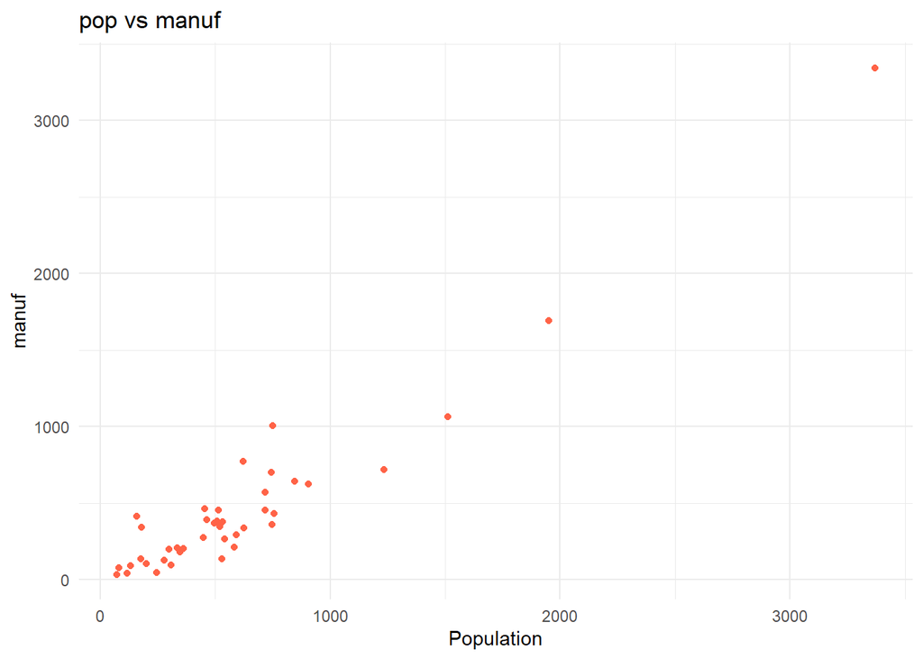

```r
#relationship between pop and manuf
ggplot(data5, aes(x = pop, y = manuf)) +
  geom_point(color = "tomato") +
  theme_minimal() +
  labs(title = "pop vs manuf", x = "Population", y = "manuf")
```

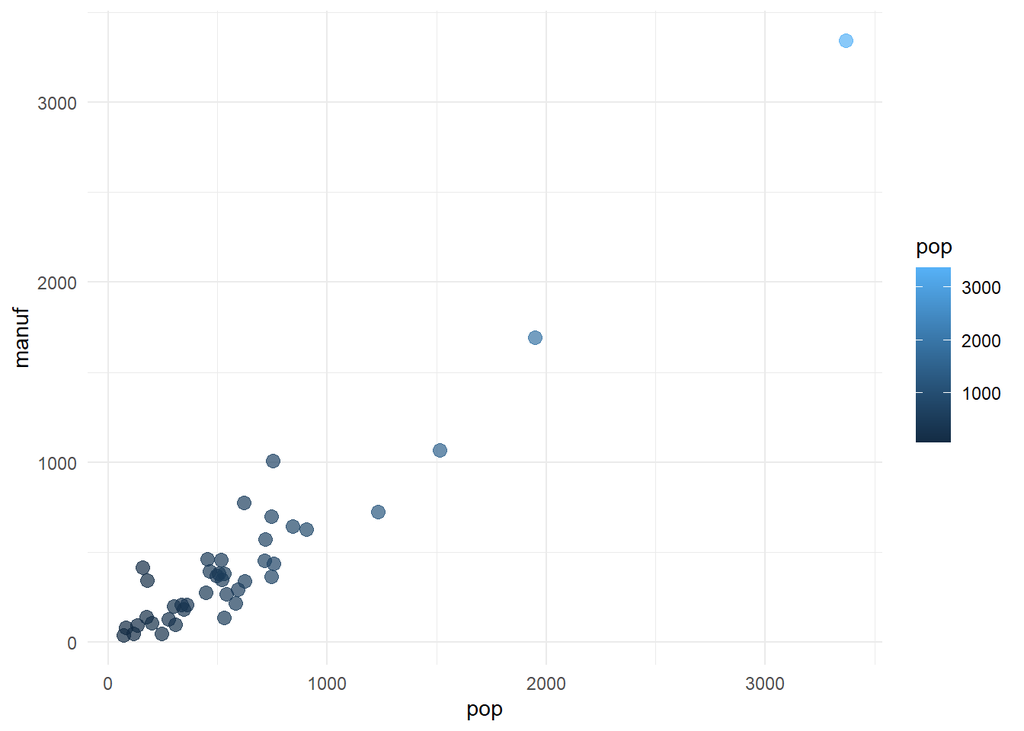

```r
ggplot(data5, aes(x = pop, y = manuf, color = pop)) +
  geom_point(size = 3, alpha = 0.7) +
  theme_minimal()
```

We identify that `manuf` and `pop` have a mean significantly larger than the median. For `manuf`, it was found that it has a mean of 463.1 and a median of 347. For `pop`, the results were 608 to 515 respectively. Furthermore, the maximum values (3344, 3369) are in order of magnitude greater than the 75th percentile (462, 717) for both variables.

With this we could infer that the dataset does not contain 41 similar cities. It contains a majority of “typical” cities and a few massive outliers, metropolitan big cities. In order to avoid that our analysis was dominated by these few outliers, we decided to use a correlation analysis to normalize our data.

We also noticed that the data is in different units, and every unit measured different things which made very important the use of the *correlation matrix* to perform this first type of analysis.

Adding up to that, we can check the standard deviation of the variables:

```r
# Calculate standard deviation for each variable.
library(dplyr)

data5_variables %>% summarise_if(is.numeric, sd)
```

```
##        so2     temp    manuf     pop     wind   precip     days
## 1 23.47227 7.227716 563.4739 579.113 1.428644 11.77155 26.50642
```

Since the standard deviations for `pop` and `manuf` are orders of magnitude larger than for other variables, we can confirm their high variance.

When we run the PCA on the correlation matrix we will do after this, we can find the directions (PCs) that will maximize the standardized variance based on the correlation relationships between the variables.

For the reason mentioned above and this one, it’s better that we use the *correlation matrix* in order to perform our PCA.

## Correlation Analysis + Correlation Matrix

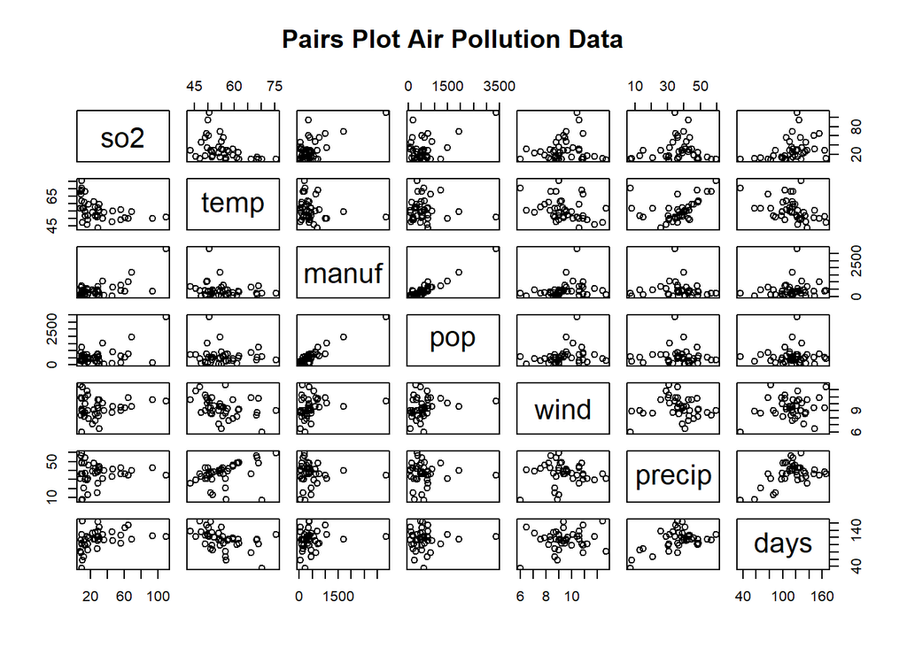

```r
# Visualize pairwise relationships between all variables.
pairs(data5_variables, main="Pairs Plot Air Pollution Data")
```

**CORRELATION MATRIX**

```r
# 1st) Calculate and display the correlation matrix.
cor_data5 <- cor(data5_variables)
cor_data5
```

```
##                so2        temp       manuf         pop        wind      precip
## so2     1.00000000 -0.43360020  0.64476873  0.49377958  0.09469045  0.05429434
## temp   -0.43360020  1.00000000 -0.19004216 -0.06267813 -0.34973963  0.38625342
## manuf   0.64476873 -0.19004216  1.00000000  0.95526935  0.23794683 -0.03241688
## pop     0.49377958 -0.06267813  0.95526935  1.00000000  0.21264375 -0.02611873
## wind    0.09469045 -0.34973963  0.23794683  0.21264375  1.00000000 -0.01299438
## precip  0.05429434  0.38625342 -0.03241688 -0.02611873 -0.01299438  1.00000000
## days    0.36956363 -0.43024212  0.13182930  0.04208319  0.16410559  0.49609671
##               days
## so2     0.36956363
## temp   -0.43024212
## manuf   0.13182930
## pop     0.04208319
## wind    0.16410559
## precip  0.49609671
## days    1.00000000
```

```r
library(GGally)
```

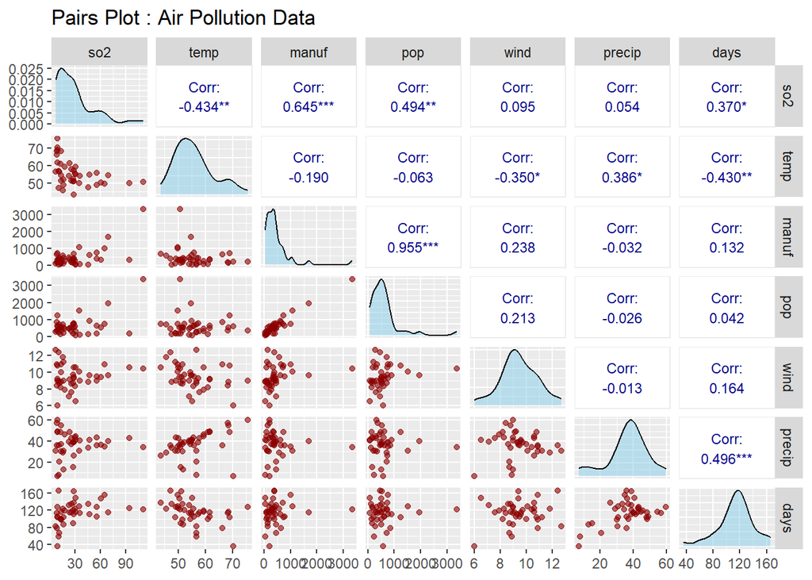

```r
p <- ggpairs(
  data5_variables,
  title = "Pairs Plot : Air Pollution Data",
  upper = list(continuous = wrap("cor", size = 3, color="darkblue")),
  lower = list(continuous = wrap("points", alpha = 0.6, size=1.5, color="darkred")),
  diag = list(continuous = wrap("densityDiag", alpha=0.5, fill="skyblue"))
)
p
```

```r
ggsave("plots/pairs_plot.png", plot = p, width = 10, height = 8, dpi = 300)
```

By looking at the plot and the correlation values between the variables we can observe that the population size and the number of manufacturing enterprises employing 20 or more workers is strongly correlated (0.955). We can see that the most populated cities in this study (looking at the initial data, data5), employ more people.

Then, we can observe that the number of manufacturing enterprises employing workers and the sulfur dioxide content of air (mg/m3) are correlated as well (0.645), which means that the manufacturing enterprises that employ 20 or more workers end up influencing so2 levels, which makes sense.

Population and so2 levels are correlated as well (0.494), and precipitation and number of days too (0.496).

Even though with a lower value, precipitation and temperature variables are correlated (0.386).

Summing everything up, the correlation matrix reveals several key relationships:

- A very strong positive correlation (0.955) between `manuf` and `pop`.
- A moderate positive correlation (0.65) between `manuf` and `so2`.

This suggests that industrial and population factors are closely linked and are associated with higher SO2 pollution.

# Principal Component Analysis (PCA)

PCA will be used to reduce the dimensionality of the dataset. By creating a smaller set of uncorrelated components, we can simplify the data while retaining most of the original variance. We will use the *correlation matrix* (`scale = TRUE`) to account for the different units and scales of the original variables.

**EIGENVALUES AND EIGENVECTORS**

```r
## 2nd) Obtain eigenvectors and eigenvalues

eigen_data5 <- eigen(cor_data5)
eigen_data5
```

```
## eigen() decomposition
## $values
## [1] 2.72811968 1.51233485 1.39497299 0.89199129 0.34677866 0.10028759 0.02551493
##
## $vectors
##               [,1]        [,2]       [,3]        [,4]       [,5]        [,6]
## [1,]  0.4896988171 -0.08457563 -0.0143502  0.40421007  0.7303942 -0.18334573
## [2,] -0.3153706901  0.08863789 -0.6771362 -0.18522794  0.1624652 -0.61066107
## [3,]  0.5411687028  0.22588109 -0.2671591 -0.02627237 -0.1641011  0.04273352
## [4,]  0.4875881115  0.28200380 -0.3448380 -0.11340377 -0.3491048  0.08786327
## [5,]  0.2498749284 -0.05547149  0.3112655 -0.86190131  0.2682549 -0.15005378
## [6,]  0.0001873122 -0.62587937 -0.4920363 -0.18393719  0.1605988  0.55357384
## [7,]  0.2601790729 -0.67796741  0.1095789  0.10976070 -0.4399698 -0.50494668
##              [,7]
## [1,]  0.149529278
## [2,] -0.023664113
## [3,] -0.745180920
## [4,]  0.649125507
## [5,]  0.015765377
## [6,] -0.010315309
## [7,]  0.008217393
```

## Justification for Number of Components Retained

### Criteria 1 => Kaiser’s Criteria

*Analyzing the results*, we should retain the first 3 PCs because there are 3 eigenvalues that are >1 (Kaiser’s Criteria).

However, there are other criteria that we should take into consideration. Now we will perform PCA to see if 3 PCs explain the majority of the variance or not.

### Criteria 2 => PCA

```r
# 3rd) Perfom PCA

pca_results <- princomp(data5_variables, cor = TRUE)

print(summary(pca_results), loadings = TRUE)
```

```
## Importance of components:
##                           Comp.1    Comp.2    Comp.3    Comp.4     Comp.5
## Standard deviation     1.6517021 1.2297702 1.1810897 0.9444529 0.58887916
## Proportion of Variance 0.3897314 0.2160478 0.1992819 0.1274273 0.04953981
## Cumulative Proportion  0.3897314 0.6057792 0.8050611 0.9324884 0.98202821
##                           Comp.6      Comp.7
## Standard deviation     0.3166822 0.159733920
## Proportion of Variance 0.0143268 0.003644989
## Cumulative Proportion  0.9963550 1.000000000
##
## Loadings:
##        Comp.1 Comp.2 Comp.3 Comp.4 Comp.5 Comp.6 Comp.7
## so2     0.490                0.404  0.730  0.183  0.150
## temp   -0.315         0.677 -0.185  0.162  0.611
## manuf   0.541 -0.226  0.267        -0.164        -0.745
## pop     0.488 -0.282  0.345 -0.113 -0.349         0.649
## wind    0.250        -0.311 -0.862  0.268  0.150
## precip         0.626  0.492 -0.184  0.161 -0.554
## days    0.260  0.678 -0.110  0.110 -0.440  0.505
```

*Analyzing the results*, we have 81% of the variance explained with the first 3 PCs (viewed in the cumulative proportion). However, if we consider 4 PCs, we will have 93% of the variance explained.

Since this is not conclusive, we should do the third criteria.

### Criteria 3 => Scree Plot

Now we have all that we need to do is a *scree plot* to see where the elbow point might be:

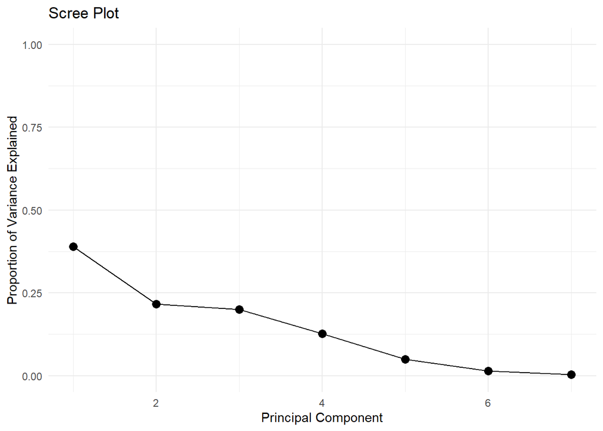

```r
library(ggplot2)

eigenvalues <- eigen_data5$values

scree_data <- data.frame(
  component = 1:length(eigenvalues),
  variance_explained = eigenvalues / sum(eigenvalues)
)
ggplot(scree_data, aes(x = component, y = variance_explained)) +
  geom_line() +
  geom_point(size=3) +
  ylim(0,1) +
  labs(title = "Scree Plot", x = "Principal Component", y = "Proportion of Variance Explained") +
  theme_minimal()
```

### Criteria 3 => Scree Plot Enhance with Kaizer crteria.

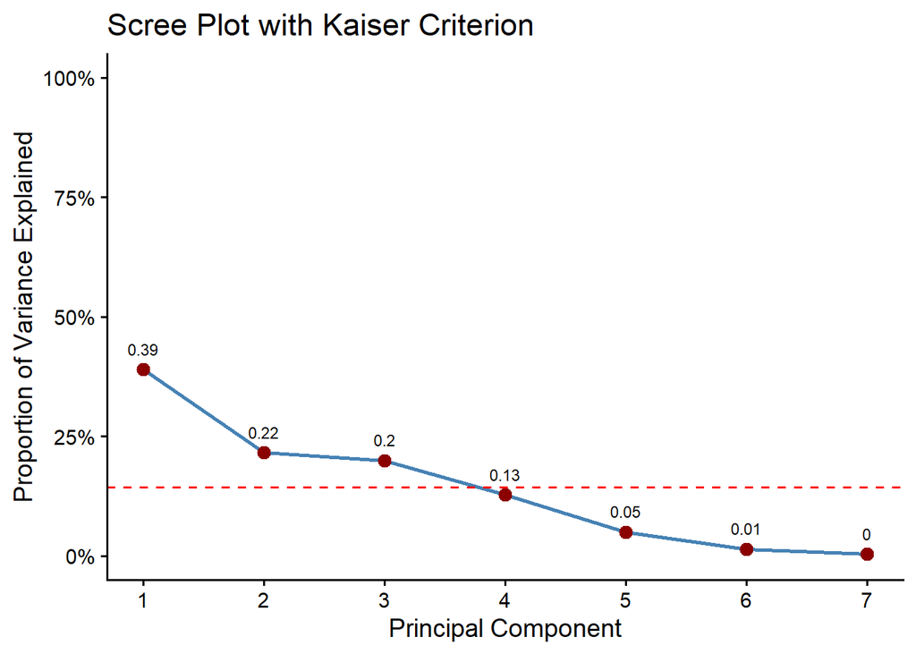

*Analyzing the results*, in this plot, the elbow point would be between PC2 and PC3. However, if we consider the other criterias we have applied before, it would be best to use 3 PCs, having approximately 81% of the variance explained.

**SO LET’S CONSIDER 3 PCs.**

Now, we need to see which are the variables that contribute more for the explanation of each principal component retained. We need to have a correlation matrix between the variables and the PCs (the loadings).

## Component Interpretation (Loadings)

```r
# Correlation between original variables and the PCs (loadings)

component_matrix <- cor(data5_variables,pca_results$scores)
component_matrix
```

```
##               Comp.1      Comp.2      Comp.3      Comp.4      Comp.5
## so2     0.8088365434  0.10400859  0.01694887  0.38175738  0.43011391
## temp   -0.5208984175 -0.10900423  0.79975860 -0.17493906  0.09567234
## manuf   0.8938494595 -0.27778184  0.31553891 -0.02481301 -0.09663572
## pop     0.8053502866 -0.34679989  0.40728458 -0.10710452 -0.20558056
## wind    0.4127189331  0.06821718 -0.36763244 -0.81402520  0.15796972
## precip  0.0003093839  0.76968782  0.58113903 -0.17372001  0.09457328
## days    0.4297383099  0.83374415 -0.12942257  0.10366381 -0.25908903
##             Comp.6       Comp.7
## so2     0.05806232  0.023884898
## temp    0.19338547 -0.003779961
## manuf  -0.01353294 -0.119030670
## pop    -0.02782473  0.103687362
## wind    0.04751936  0.002518265
## precip -0.17530696 -0.001647705
## days    0.15990761  0.001312596
```

We only need to look into the the 3 first PCs, since we determined we are going to use the first three.

To verify that we made the right decisions:

# Tables to summarize the loadings

```r
library(gridExtra)
```

```r
library(grid)

# Create table of loadings for the 3 PCs
loadings_table <- data.frame(
  Variable = c("so2", "temp", "manuf", "pop", "wind", "precip", "days"),
  PC1 = c(0.8088365434, -0.5208984175, 0.8938494595, 0.8053502866, 0.4127189331, 0.0003093839, 0.4297383099),
  PC2 = c(0.10400859, -0.10900423, -0.27778184, -0.34679989, 0.06821718, 0.76968782, 0.83374415),
  PC3 = c(0.01694887, 0.79975860, 0.31553891, 0.40728458, -0.36763244, 0.58113903, -0.12942257)
)

# Create a visual table.
loadings_plot <- tableGrob(
  loadings_table,
  rows = NULL,
  theme = ttheme_default(
    core = list(fg_params = list(hjust = 0.5, x = 0.5)),
    colhead = list(fg_params = list(fontface = "bold", hjust = 0.5))
  )
)

# # Export as png
if(!dir.exists("./plots")) dir.create("./plots")
png("./plots/pca_loadings_table.png", width = 900, height = 400)
grid.draw(loadings_plot)
# dev.off()
```

# Style 2 of table.

```r
library(knitr)

library(kableExtra)
loadings_table <- data.frame(
  Variable = c("so2", "temp", "manuf", "pop", "wind", "precip", "days"),
  PC1 = c(0.8088365434, -0.5208984175, 0.8938494595, 0.8053502866, 0.4127189331, 0.0003093839, 0.4297383099),
  PC2 = c(0.10400859, -0.10900423, -0.27778184, -0.34679989, 0.06821718, 0.76968782, 0.83374415),
  PC3 = c(0.01694887, 0.79975860, 0.31553891, 0.40728458, -0.36763244, 0.58113903, -0.12942257)
)

kable(loadings_table, format = "html", digits = 4, align = "c",
      col.names = c("Variable", "PC1", "PC2", "PC3")) %>%
  kable_styling(full_width = FALSE, position = "center", bootstrap_options = c("striped", "hover"))
```

| Variable | PC1 | PC2 | PC3 |
| --- | --- | --- | --- |
| so2 | 0.8088 | 0.1040 | 0.0169 |
| temp | -0.5209 | -0.1090 | 0.7998 |
| manuf | 0.8938 | -0.2778 | 0.3155 |
| pop | 0.8054 | -0.3468 | 0.4073 |
| wind | 0.4127 | 0.0682 | -0.3676 |
| precip | 0.0003 | 0.7697 | 0.5811 |
| days | 0.4297 | 0.8337 | -0.1294 |

Let’s prove that with:

```r
# Apply the rule for the 1st PC
# lambda1 / p

sqrt(eigen_data5$values[1]/8)
```

```
## [1] 0.5839649
```

We considered everything above this value for PC1.

```r
# Apply the rule for the 2nd PC
# lambda1 / p

sqrt(eigen_data5$values[2]/8)
```

```
## [1] 0.4347894
```

We considered everything above this value for PC2.

```r
# Apply the rule for the 3rd PC
# lambda1 / p

sqrt(eigen_data5$values[3]/8)
```

```
## [1] 0.4175783
```

We considered everything above this value for PC3.

## Visualization of the Data

```r
######Scores
#Put the scores in their own variable to use
scores <- as.data.frame(pca_results$scores)

#City names
scores$city <- data5$city
```

The next 3 graphics are on the first 3 PCs:

# Biplots.

## PC1 vs PC2

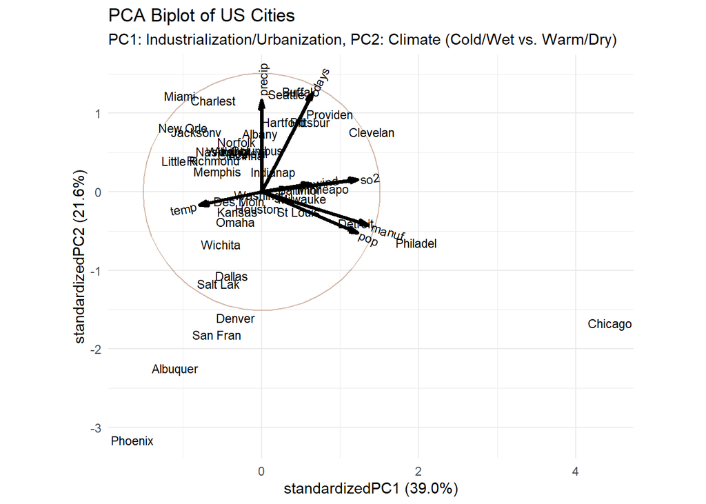

## PC2 vs PC3

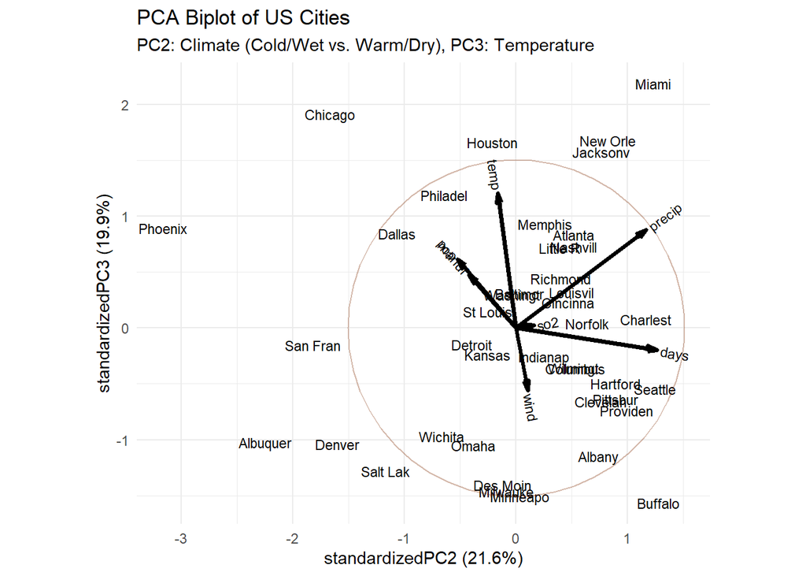

## PC1 vs PC3

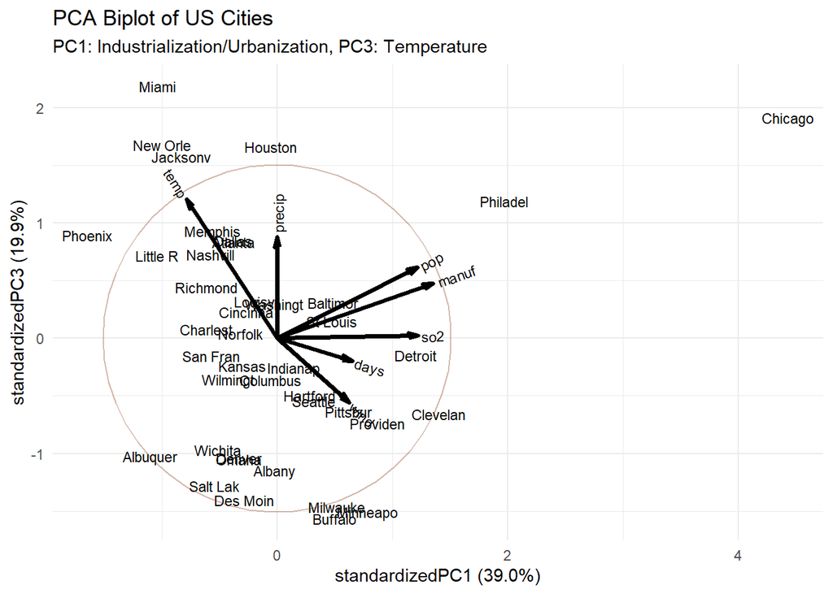

## Enhance Option 1 : PC1 vs PC2.

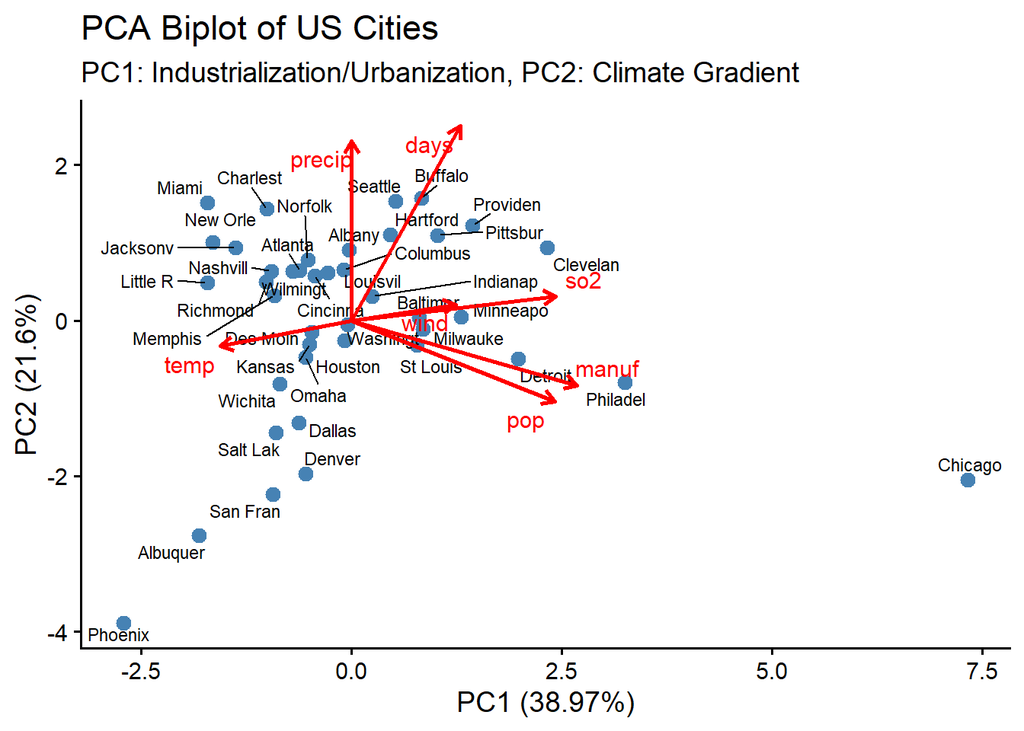

```
## Aesthetic mapping:
```

```
## Aesthetic mapping:
```

## Enhance Option 1 PC2 vs PC3.

## Option 1

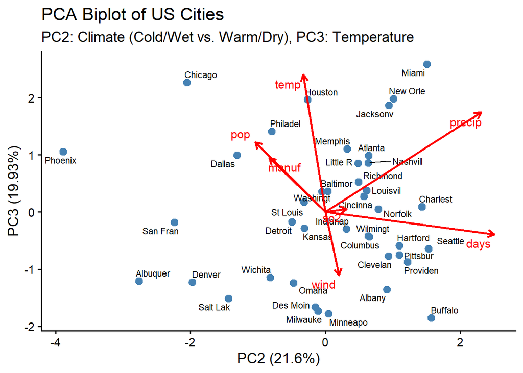

```
## Aesthetic mapping:
```

```
## Aesthetic mapping:
```

## Enhance Option 1 PC1 vs PC3.

## Option 1.

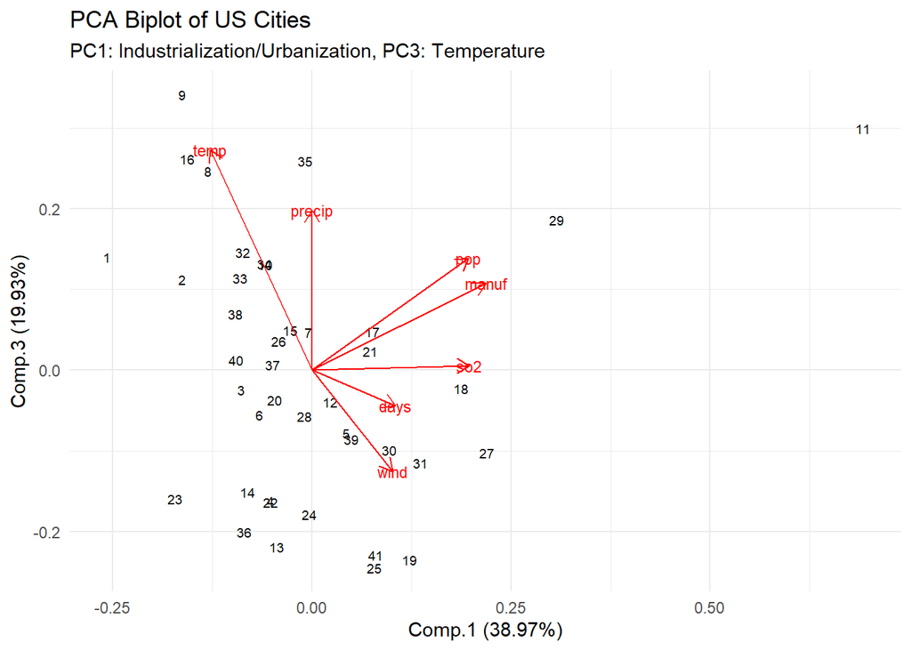

## OPtion 2.

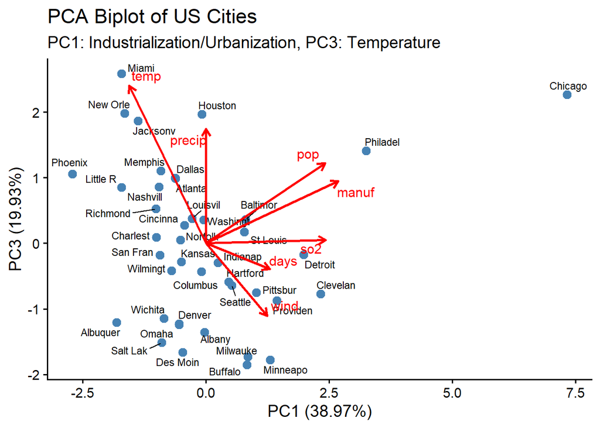

## 3D plots.

The biplot provides a visual confirmation of our interpretations and shows how cities relate to these new axes.

So, if we did a graphic for the first 3 PCs:

*This 3D graphic is not visible in the pfd format.*

```r
library(plotly)
# Supondo que você tenha feito o PCA:
data5_2 <- prcomp(data5_variables, scale. = TRUE)

pca_scores <- as.data.frame(data5_2$x)

raw_standardized_data <- as.data.frame(scale(data5_variables))

pac_socres_data <- pc_scores_data <- as.data.frame(pca_results$scores[, 1:3])

var_explained <- (data5$sdev)^2 / sum((data5$sdev)^2)

pc1_label <- paste0("PC1 (", round(var_explained[1] * 100, 1), "%)")
pc2_label <- paste0("PC2 (", round(var_explained[2] * 100, 1), "%)")
pc3_label <- paste0("PC3 (", round(var_explained[3] * 100, 1), "%)")

plot_ly(pca_scores,
        x = ~PC1,
        y = ~PC2,
        z = ~PC3,
        type = 'scatter3d',
        mode = 'markers',
        text = rownames(pca_scores),
        marker = list(size = 4)
)%>%
  layout(
    title = "3D Graphic with the first 3 PCs",
    scene = list(
      xaxis = list(title = pc1_label),
      yaxis = list(title = pc2_label),
      zaxis = list(title = pc3_label)
    )
  )
```

[interactive chart not shown]

## Interactive 3D Scatter Plot (Another Version)

A 2D biplot can only show two components at a time. Since our first three components capture over 80% of the variance, an interactive 3D scatter plot is an effective way to visualize the relationships between cities across these dimensions simultaneously. Compare this implementation with your previous attempt to understand how to leverage existing PCA results and correctly label axes.

```r
library(plotly)

# 1. Extract the scores and city names from our existing PCA results
scores_df <- as.data.frame(pca_results$scores)
scores_df$city <- data5$city

# 2. Get the proportion of variance explained for axis labels
# This comes from the summary of our pca_results object
pca_summary <- summary(pca_results)
variance_explained <- pca_summary$sdev^2 / sum(pca_summary$sdev^2)

pc1_label <- paste0("PC1 (", round(variance_explained[1] * 100, 1), "%)")
pc2_label <- paste0("PC2 (", round(variance_explained[2] * 100, 1), "%)")
pc3_label <- paste0("PC3 (", round(variance_explained[3] * 100, 1), "%)")

# 3. Create the interactive 3D plot
plot_ly(data = scores_df,
        x = ~Comp.1, y = ~Comp.2, z = ~Comp.3,
        text = ~city, # Use city names for hover text
        type = 'scatter3d',
        mode = 'markers',
        marker = list(size = 5, color = ~Comp.1, colorscale = 'Viridis', showscale = TRUE, colorbar = list(title = pc1_label))) %>%
  layout(
    title = "Interactive 3D PCA Scatter Plot of US Cities (Improved)",
    scene = list(
      xaxis = list(title = pc1_label),
      yaxis = list(title = pc2_label),
      zaxis = list(title = pc3_label)
    )
  )
```

[interactive chart not shown]

# Cluster Analysis

Now we will do a completely different analysis and group similar cities using *hierarchical clustering*. We will perform this in two forms, with the original data and with the PCA scores, since it’s normal to use the latter in some types of analyses.

```r
#Load the libraries needed
library(tidyverse) #data manipulation
library(cluster) #clustering algorithms
library(factoextra) #clustering visualization
library(dendextend) #for comparing two dendograms
library(laGP) #squared Euclidean distance
library(metan) #clustering algorithms
library(tidygeocoder) # for geocoding
```

```r
library(maps) # for map data
```

## Cluster Analysis with the Original Data

*First*, we can view again the correlation matrix between the original variables:

```r
cor_data5
```

```
##                so2        temp       manuf         pop        wind      precip
## so2     1.00000000 -0.43360020  0.64476873  0.49377958  0.09469045  0.05429434
## temp   -0.43360020  1.00000000 -0.19004216 -0.06267813 -0.34973963  0.38625342
## manuf   0.64476873 -0.19004216  1.00000000  0.95526935  0.23794683 -0.03241688
## pop     0.49377958 -0.06267813  0.95526935  1.00000000  0.21264375 -0.02611873
## wind    0.09469045 -0.34973963  0.23794683  0.21264375  1.00000000 -0.01299438
## precip  0.05429434  0.38625342 -0.03241688 -0.02611873 -0.01299438  1.00000000
## days    0.36956363 -0.43024212  0.13182930  0.04208319  0.16410559  0.49609671
##               days
## so2     0.36956363
## temp   -0.43024212
## manuf   0.13182930
## pop     0.04208319
## wind    0.16410559
## precip  0.49609671
## days    1.00000000
```

*Secondly*, to perform and obtain the *dendograms* we need to determine the distances (to cluster the groups).

[output not shown]

[output cut: 191 more lines]

[output not shown]

The dissimilarity matrix is calculated from the data matrix and it contains the values measuring the dissimilarity/similarity between the elements of each pair. Euclidean distance should not be used when we have different variables measured in different units so, in our case we should use Mahalanobis distance, because, besides the different units, we have correlated variables in the correlation matrix, mainly manuf and pop. So, this method would solve our problem with different scales while also the effects of correlation between variables.

To determine the optimal number of clusters in a dendogram for hierarchical methods and for the original data, we used the silhouette width. The best value of k is the one with the largest average silhouette.

## Elbow Method

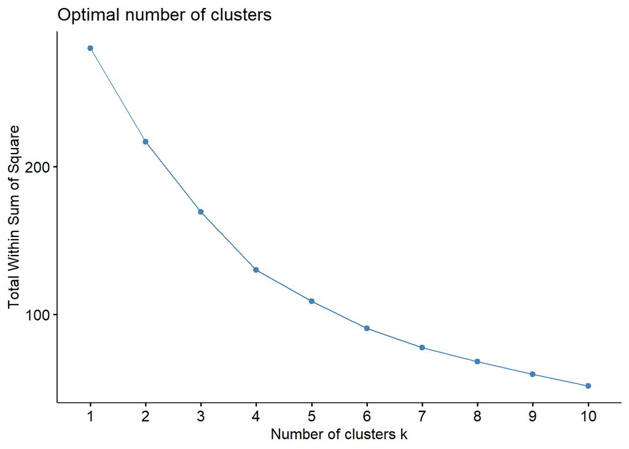

```r
#non hierarchical, n da para usar. Silhoette da para usar.
library(factoextra)
fviz_nbclust(data5_v, hcut, method = "wss")
```

(Here we can see the elbow point at 3 clusters, or even 4 clusters, but we considered the optimal number of clusters k=3)

**Let´s perform the Hierarchical Clustering**.

### SINGLE LINKAGE

```r
hc1_s <- agnes(dist_data5, method = "single")
hc1_s$merge
```

```
##       [,1] [,2]
##  [1,]   -8  -16
##  [2,]  -13  -22
##  [3,]  -33  -38
##  [4,]  -10  -32
##  [5,]   -7  -12
##  [6,]  -17  -21
##  [7,]  -15    3
##  [8,]    7  -28
##  [9,]    4    8
## [10,]    5    6
## [11,]   -4  -36
## [12,]   10    9
## [13,]   -2   12
## [14,]    2  -20
```

[output cut: 26 more lines]

```r
hc1_s$order
```

```
##  [1]  1  2  7 12 17 21 10 32 15 33 38 28 26 13 22 20  6  8 16  9 39 40 37  5 24
## [26] 30 19 41 14 27 18 25 34 35 31  3  4 36 23 29 11
```

```r
hc1_s$ac
```

```
## [1] 0.7033724
```

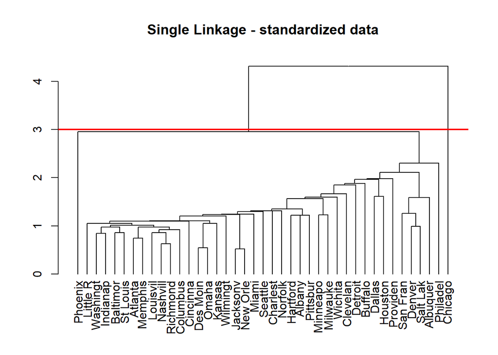

```r
#Dendrogram
dend1_s <- as.dendrogram(hc1_s)
#labels(dend1_s) <- data5$city
order_in_dend <- order.dendrogram(dend1_s)
labels(dend1_s) <- data5$city[order_in_dend]
plot(dend1_s, main = "Single Linkage - standardized data")
abline(h = 3, col = "red", lwd = 2)
```

## Now we can do the *Cophenetic Coefficient*.

```r
#Cophenetic Coefficient
clust_single_s <- hclust(dist_data5, method="single")

#Cophenetic matrix (delta matrix - obtained based on the dendogram)
coph_1_s <- cophenetic(clust_single_s)

#Cophenetic coefficient
cor(dist_data5, coph_1_s)
```

```
## [1] 0.8533611
```

### COMPLETE LINKAGE

```r
hc2_s <- agnes(dist_data5, method = "complete")
hc2_s$merge
```

```
##       [,1] [,2]
##  [1,]   -8  -16
##  [2,]  -13  -22
##  [3,]  -33  -38
##  [4,]  -10  -32
##  [5,]   -7  -12
##  [6,]  -17  -21
##  [7,]  -15    3
##  [8,]   -4  -36
##  [9,]    5  -20
## [10,]  -26  -28
## [11,]   -5  -24
## [12,]  -19  -41
## [13,]    1   -9
## [14,]   -2    4
```

[output cut: 26 more lines]

```r
hc2_s$order
```

```
##  [1]  1  3 23  4 36 13 22 14  2 10 32  8 16  9 34 35  5 24 30 39  6 37  7 12 20
## [26] 17 21 15 33 38 26 28 40 31 19 41 25 18 27 29 11
```

## AC Value Complete

```r
hc2_s$ac
```

```
## [1] 0.8376211
```

The AC value is high.

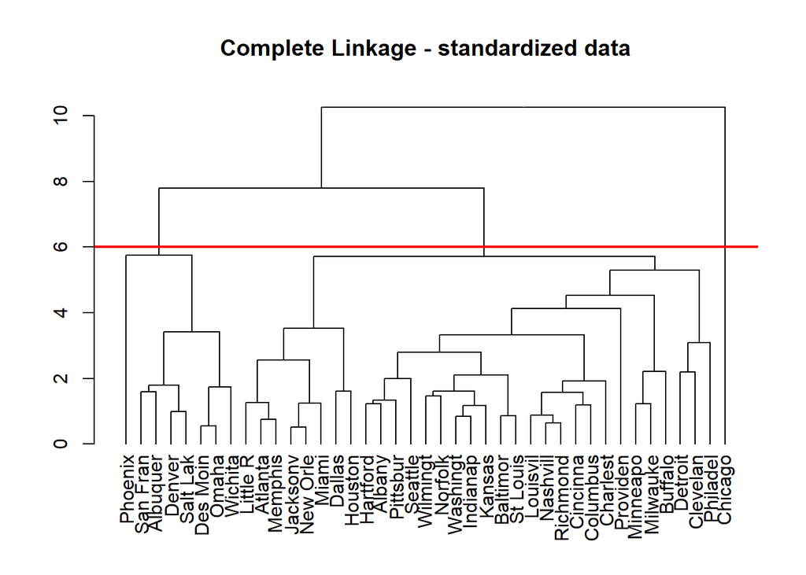

```r
#Dendrogram
dend2_s <- as.dendrogram(hc2_s)
#labels(dend1_s) <- data5$city
order_in_dend2 <- order.dendrogram(dend2_s)
labels(dend2_s) <- data5$city[order_in_dend2]
plot(dend2_s, main = "Complete Linkage - standardized data")
abline(h = 6, col = "red", lwd = 2)
```

## Elbow method for the best linkage method.

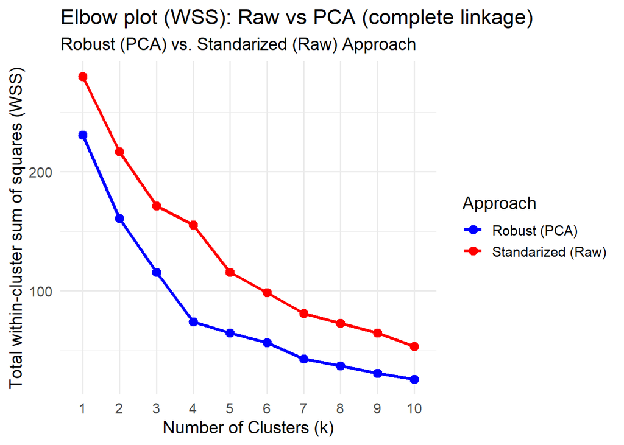

```r
raw_standardized_data <- data5_v

# Assuming 'pca_scores' are your 3 PC scores
# and 'hc_complete_pca' is your hclust object from Complete Linkage
#
# The fviz_nbclust function can take the original data and apply
# the clustering for you for a range of k.


library(factoextra)
elbow_plot_raw <- fviz_nbclust(raw_standardized_data,
  FUNcluster = function(x, k) hcut(x, k, hc_method = "complete"),
  method = "wss")

elbow_plot_pca <- fviz_nbclust(pac_socres_data,
  FUNcluster = function(x, k) hcut(x, k, hc_method = "complete"),
  method = "wss")

 # 2. Extract and combine
 data_elbow_pca <- elbow_plot_pca$data
 data_elbow_raw <- elbow_plot_raw$data

 data_elbow_pca$Approach <- "Robust (PCA)"
 data_elbow_raw$Approach <- "Standarized (Raw)"

 combined_elbow_data <- rbind(data_elbow_pca, data_elbow_raw)

 # 3. Create superior comparison plot
 ggplot(combined_elbow_data, aes(x = clusters, y = y, group = Approach, color = Approach)) +
   geom_line(linewidth = 1.2) +
   geom_point(size = 3) +
  labs(title = "Elbow plot (WSS): Raw vs PCA (complete linkage)",
       subtitle = "Robust (PCA) vs. Standarized (Raw) Approach",
       x = "Number of Clusters (k)",
       y = "Total within-cluster sum of squares (WSS)"
   ) +
   theme_minimal(base_size = 14) +
   scale_color_manual(values = c("Robust (PCA)" = "blue", "Standarized (Raw)" = "red"))
```

## Silhouette for raw data

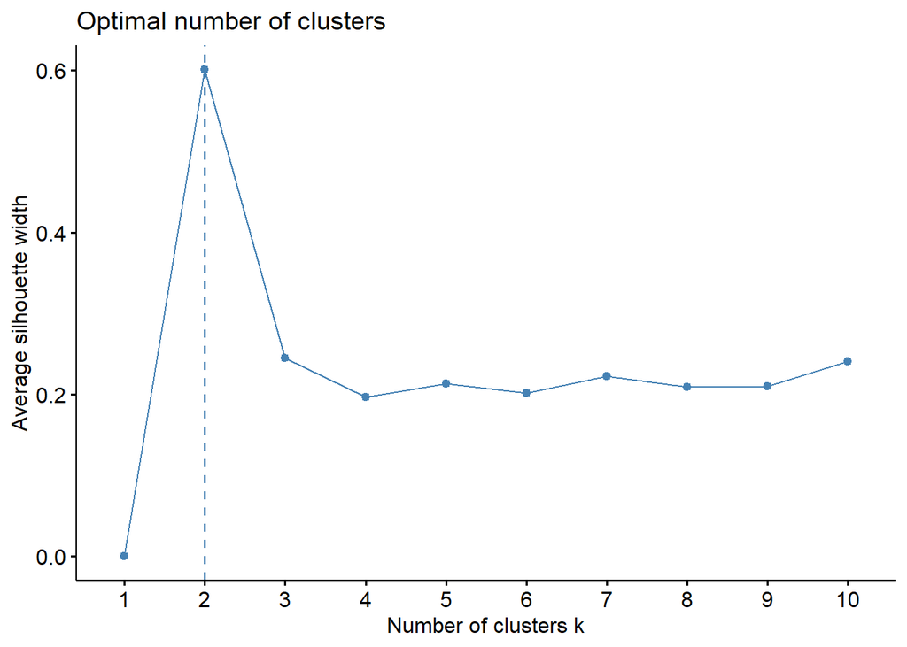

```r
# Silhouette for raw data
fviz_nbclust(raw_standardized_data,
    FUNcluster = function(x, k) hcut(x, k, hc_method = "complete"),
    method = "silhouette")
```

## Silhouette combine

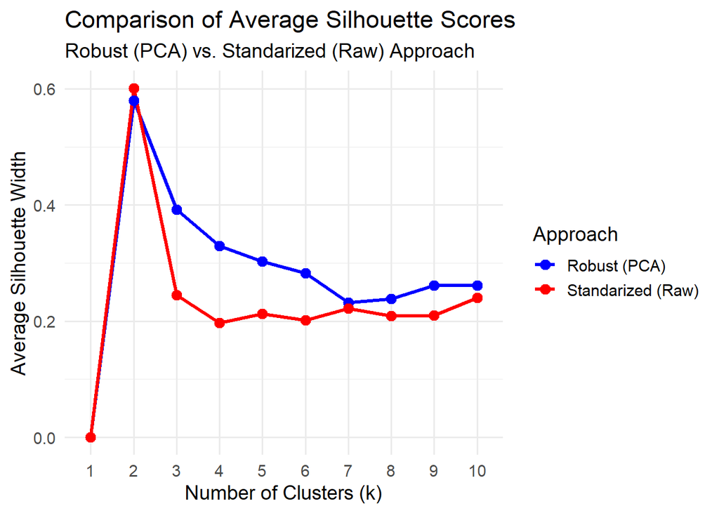

```r
# 1. Generate data for Silhouette method
 sil_plot_pca <- fviz_nbclust(pac_socres_data, FUNcluster = function(x, k) hcut(x, k, hc_method = "complete"), method = "silhouette")
 sil_plot_raw <- fviz_nbclust(raw_standardized_data, FUNcluster = function(x, k) hcut(x, k, hc_method =  "complete"), method = "silhouette")

 # 2. Extract and combine
 data_sil_pca <- sil_plot_pca$data
 data_sil_raw <- sil_plot_raw$data

 data_sil_pca$Approach <- "Robust (PCA)"
 data_sil_raw$Approach <- "Standarized (Raw)"

 combined_sil_data <- rbind(data_sil_pca, data_sil_raw)

 # 3. Create superior comparison plot
 ggplot(combined_sil_data, aes(x = clusters, y = y, group = Approach, color = Approach)) +
   geom_line(linewidth = 1.2) +
   geom_point(size = 3) +
   labs(
     title = "Comparison of Average Silhouette Scores",
     subtitle = "Robust (PCA) vs. Standarized (Raw) Approach",
     x = "Number of Clusters (k)",
     y = "Average Silhouette Width"
   ) +
   theme_minimal(base_size = 14) +
   scale_color_manual(values = c("Robust (PCA)" = "blue", "Standarized (Raw)" = "red"))
```

[figure not shown]

```r
plot(dend2_s, main="Complete Linkage - 4 clusters")
# k =  clusters considered
rect.hclust(hc2_s, k=3, border = 2:4)
```

## Now we can do the *Cophenetic Coefficient*. complete

```r
#Cophenetic Coefficient
clust_complete_s <- hclust(dist_data5, method="complete")

#Cophenetic matrix (delta matrix - obtained based on the dendogram)
coph_2_s <- cophenetic(clust_complete_s)

#Cophenetic coefficient
cor(dist_data5, coph_2_s)
```

```
## [1] 0.6873652
```

It’s a smaller value than the *Single Linkage* one.

But using the silhouette method to determine the optimal number of clusters:

```r
# Define a range of clusters to test
k_values <- 2:6

for (k in k_values) {
  clusters <- cutree(hc2_s, k = k)           # cluster assignments
  sil <- silhouette(clusters, dist_data5)    # silhouette calculation
  avg_sil <- mean(sil[, 3])                  # average silhouette width
  cat("k =", k, "Average silhouette width =", round(avg_sil, 3), "\n")
}
```

```
## k = 2 Average silhouette width = 0.601
## k = 3 Average silhouette width = 0.245
## k = 4 Average silhouette width = 0.197
## k = 5 Average silhouette width = 0.213
## k = 6 Average silhouette width = 0.202
```

The k with highest average silhouette width, k=2, is the optimal number of clusters when using this method.

Considering 2 clusters:

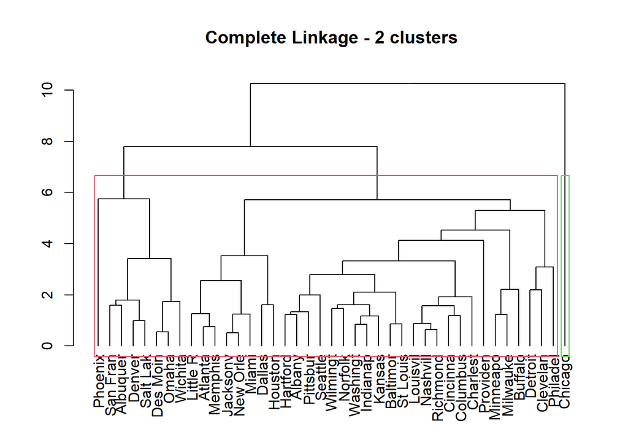

```r
plot(dend2_s, main="Complete Linkage - 2 clusters")
# k =  clusters considered
rect.hclust(hc2_s, k=2, border = 2:4)
```

### WARD LINKAGE

```r
hc3_s <- agnes(dist_data5, method = "ward")
hc3_s$merge
```

```
##       [,1] [,2]
##  [1,]   -8  -16
##  [2,]  -13  -22
##  [3,]  -33  -38
##  [4,]  -10  -32
##  [5,]   -7  -12
##  [6,]  -17  -21
##  [7,]  -15  -28
##  [8,]   -4  -36
##  [9,]    7  -26
## [10,]   -5  -24
## [11,]    5  -20
## [12,]  -19  -41
## [13,]   -2    3
## [14,]   10  -30
```

[output cut: 26 more lines]

```r
hc3_s$order
```

```
##  [1]  1  3 23  4 36  2 33 38 10 32 15 28 26 40  6 37  7 12 20 17 21  8 16  9 34
## [26] 35  5 24 30 39 31 18 27 29 13 22 14 19 41 25 11
```